# Supplementary Figure 4b

CCND1 expression in PC3 stable cell lines

Jason T. Serviss

31/01/2017

#### *Introduction*

To further investigate the characteristics of the miR34a asRNA stable lines, we measured the expression level of known miR34a target cyclin D1. miR34a has been previously shown to inhibit cell cycle progression, partially via its regulation of cyclin D1.

#### *Methods*

*Cell culture and QPCR*

All cell lines were cultured at 5% CO2 and 37° C with PC3 cells in RPMI (Hyclone) and 2 mM L-glutamine. All growth mediums were supplemented with 10% heat-inactivated FBS and 50 μg/ml of streptomycin and 50 μg/ml of penicillin. Cells were seeded at 2x10^5 cells per well in a 12-well plate. After 24 hours, RNA was extracted using the RNeasy mini kit (Qiagen) and subsequently treated with DNase (Ambion Turbo DNA-free, Life Technologies). 500ng RNA was used for cDNA synthesis using MuMLV (Life Technologies) and a 1:1 mix of oligo(dT) and random nanomers. QPCR was carried out using KAPA 2G SYBRGreen (Kapa Biosystems) using the Applied Biosystems 7900HT machine with the cycling conditions: 95 °C for 3 min, 95 °C for 3 s, 60 °C for 30 s.

*Analysis*

Two technical replicates were included for each sample and each QPCR run. Delta ct was calculated by subtracting the mean of the technical replicates for each sample from the mean value for the technical replicates from the house keeping gene for the corresponding sample. Delta-delta ct was calculated for each sample by subtracting the median dct value for the corresponding mock samples. Six independant experiments (biological replicates) were performed in total. The Student’s t-test was used to compare the mock and miR34a asRNA overexpressing group’s delta-delta ct values with the null hypothesis that there was no difference in the two group’s means.

*Primers*

```r
primers <- data.frame(
    name=c(
        "CCND1 Fwd",
        "CCND1 Rev",
        "B-actin_F",
        "B-actin_R"
    ),
    sequence=c(
        "CGT GGC CTC TAA GAT GAA GG",
        "CTG GCA TTT TGG AGA GGA AG",
        "AGG TCA TCA CCA TTG GCA ATG AG",
        "CTT TGC GGA TGT CCA CGT CA"
    )
)
primers
```

| name | sequence |
| --- | --- |
| CCND1 Fwd | CGT GGC CTC TAA GAT GAA GG |
| CCND1 Rev | CTG GCA TTT TGG AGA GGA AG |
| B-actin_F | AGG TCA TCA CCA TTG GCA ATG AG |
| B-actin_R | CTT TGC GGA TGT CCA CGT CA |

#### *Results*

```r
data <- getData("Supplementary Figure 4b")

#calculate dct
groups <- c("condition", "Biological Replicate", "Cell line", "gene")
gois <- c("CCND1")

data <- data %>%
  technicalMeans(., groups) %>%
  dct(., gois, Actin, groups, F)

#calculate ddct
groups[groups == "gene"] <- "GOI"
logical <- tibble(
  condition = pull(data, condition) == "mock"
)

data <- data %>%
  ddct(., logical, groups) %>%
  folds(.)

#calculate stats
stats <- calcStats(data, condition, "mock", groups) %>%
  pFormat(.)
```

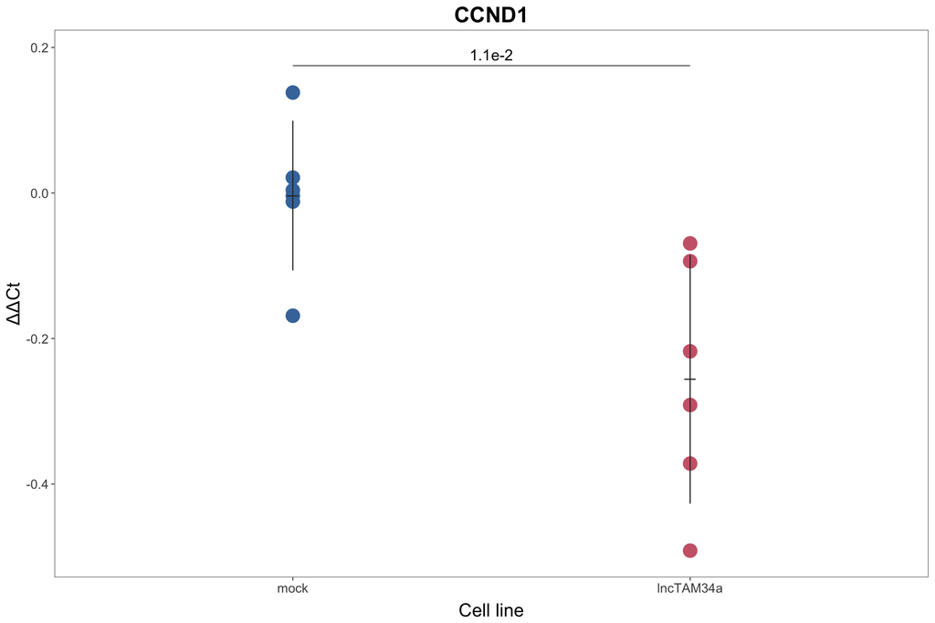

```r
p <- ggplot(data = NULL) +
  geom_dotplot(
    data = data,
    aes(
      x = condition,
      y = log2fold,
      fill = condition
    ),
    binwidth = 1/200,
    colour = NA,
    #alpha = 0.5,
    position = position_dodge(width = 0.9),
    binaxis = 'y',
    stackdir = 'center',
    dotsize = 4,
    show.legend = TRUE
  ) +
  scale_y_continuous("\u0394\u0394Ct") +
  labs(
    x = "Cell line",
    title = "CCND1"
  ) +
  guides(fill = FALSE)

markdown <- p +
  geom_linerange(
    data = stats,
    aes(
      x = condition,
      ymin = CI95l,
      ymax = CI95h
    ),
    colour = "gray20"
  ) +
  geom_point(
    data = stats,
    aes(
      x = condition,
      y = mean
    ),
    colour = "gray20",
    size = 6,
    shape = 95
  ) +
  geom_segment(
    aes(
      x = 1,
      y = 0.175,
      xend = 2,
      yend = 0.175
    ),
    colour = "grey43"
  ) +
  geom_label(
    data = stats,
    aes(
      x = 1.5,
      y = 0.19,
      label = pFormat
    ),
    label.size = 0,
    label.padding = unit(0.01, "lines"),
    show.legend = FALSE,
    fill = "white",
    size = 5,
    family = "Arial Unicode MS"
  )

plotRmarkdown(markdown)
```

```r
pdf <- p +
  geom_linerange(
    data = stats,
    aes(
      x = condition,
      ymin = CI95l,
      ymax = CI95h
    ),
    colour = "grey30",
    size = 0.3
  ) +
  geom_point(
    data = stats,
    aes(
      x = condition,
      y = mean
    ),
    colour = "grey30",
    shape = 95,
    size = 4
  ) +
  geom_segment(
    aes(
      x = 1,
      y = 0.175,
      xend = 2,
      yend = 0.175
    ),
    colour = "grey30",
    size = 0.3
  ) +
  geom_label(
    data = stats,
    aes(
      x = 1.5,
      y = 0.2,
      label = pFormat
    ),
    label.size = 0,
    label.padding = unit(0.01, "lines"),
    show.legend = FALSE,
    fill = "white",
    colour = "grey30",
    size = 2.5,
    family = "Arial Unicode MS"
  )

figure <- plotPDF(pdf)

# path <- file.path("~/GitHub/miR34a_asRNA_project/inst", fileMap(type = "pdf")["Figure 3-Supplement 2a"][[1]])
# ggsave(
#   plot = figure,
#   filename = path,
#   device = cairo_pdf,
#   height = 60,
#   width = 43,
#   units = "mm"
# )
```

Q-PCR showing cyclin D1 levels in PC3 miR34a asRNA over-expressing stable lines. The points represent the values obtained from each independant experiment (n = 6). 95% confidence interval (vertical black lines), mean (horizontal black lines), and p-values are shown with the horizontal line under the p-value indicating the comparison that was tested.

#### *Conclusions*

CCND1 expression levels are decreased in PC3 cell lines stably over-expressing miR34a asRNA.